# Sematic Audio Descriptor Analysis

## Intro

The Semantic Audio project attempts to understand the subjective terms people apply to different kinds of audio processing. http://www.semanticaudio.co.uk.

Eg. is an EQ **warm** or **bright**?

I downloaded their data to investigate. There aren’t that many rows, and the EQ dominates, as you can see below by the number of reports for each type. Is that because people really use EQ that much more than the other plug-ins? I don’t know, because I haven’t tried to cross-reference these data with anything else. But it’s not a ridiculous assumption.

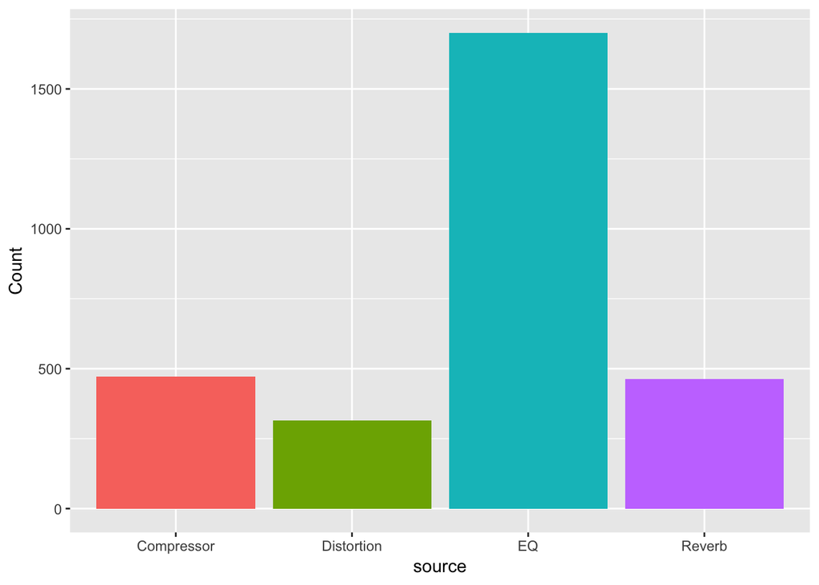

Interestingly, they have audio features for each row, which could in principle be useful to tag against words, as they do on their site (with mulitdimensional scaling). Here, I’m just going to explore the use of language, descriptions of effects and instruments.

## Instruments

Here are the instruments referred to in the dataset, broken down by effect processing type. Note that I’ve aggregated them by keyword search, so for example “guitar”, “acoustic gutiar”, and “tanglewood” are all grouped as “Guitar”. This massively helps to get manageable data, at the expense of some detail.

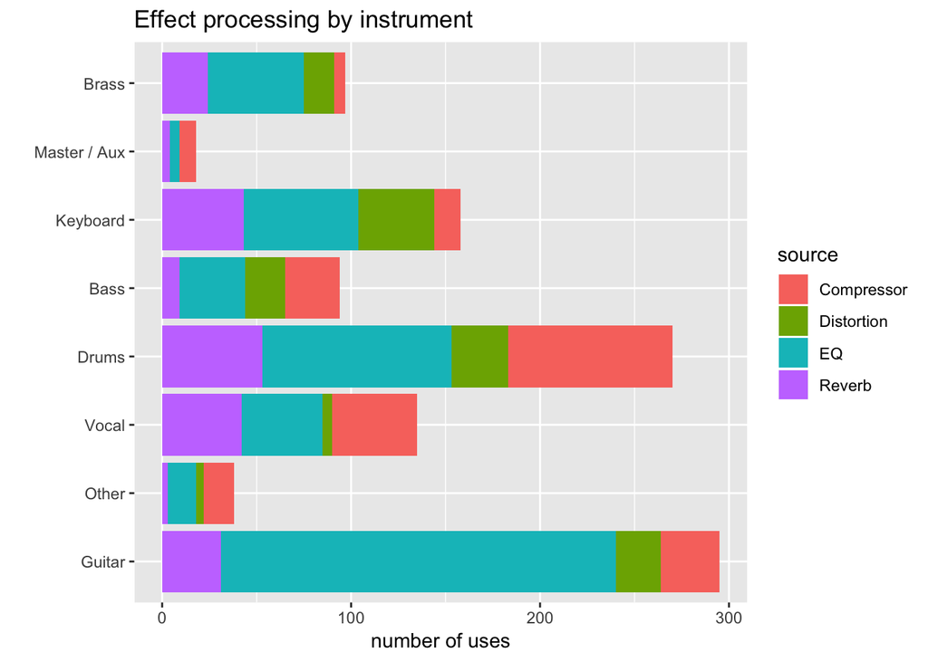

So we have a reasonable split of instruments and FX here, though guitar EQ dominates. Note that less than half of these data actually have an instrument label :(

```r
# total row count:
nrow(tokenised)
```

```
## [1] 2953
```

```r
# rows with 'instrument' set:
tokenised  %>% filter(instrument != "(Missing)") %>% nrow()
```

```
## [1] 1105
```

# Words

But which words do people use to describe the processing? Here’s a list of the most popular words used. I’ve ignored words used less than eight times to keep the chart small enough, but still it’s hard to read beacuse of the massive overuse of *warm* and *bright*.

Note that (as for the instruments) I’ve cleaned these words up a little. Anything beginning with a capital letter has been preprocessed a little for misspellings and stemming. For example, aggregating “crips”, “crisp” and “crispy” to *Crisp*. If it begins with a lowercase letter, it’s verbatim.

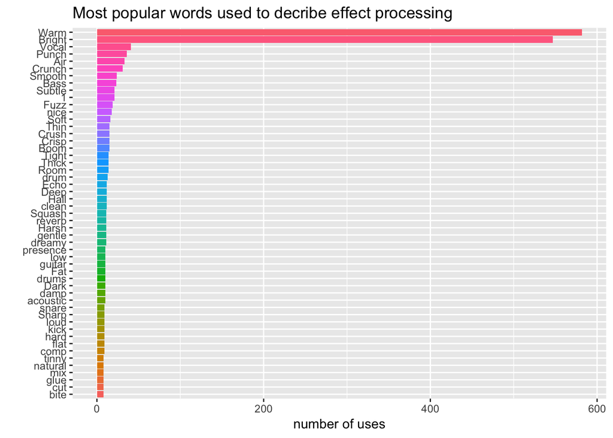

As you can see, the words *warm* and *bright* are overused (mainly for EQing guitar, as we’ll see later).

# Compresssor words

Despite my better judgement, I’m going to press on. Here’s an attempt to look at how different words are used to describe compressor settings.

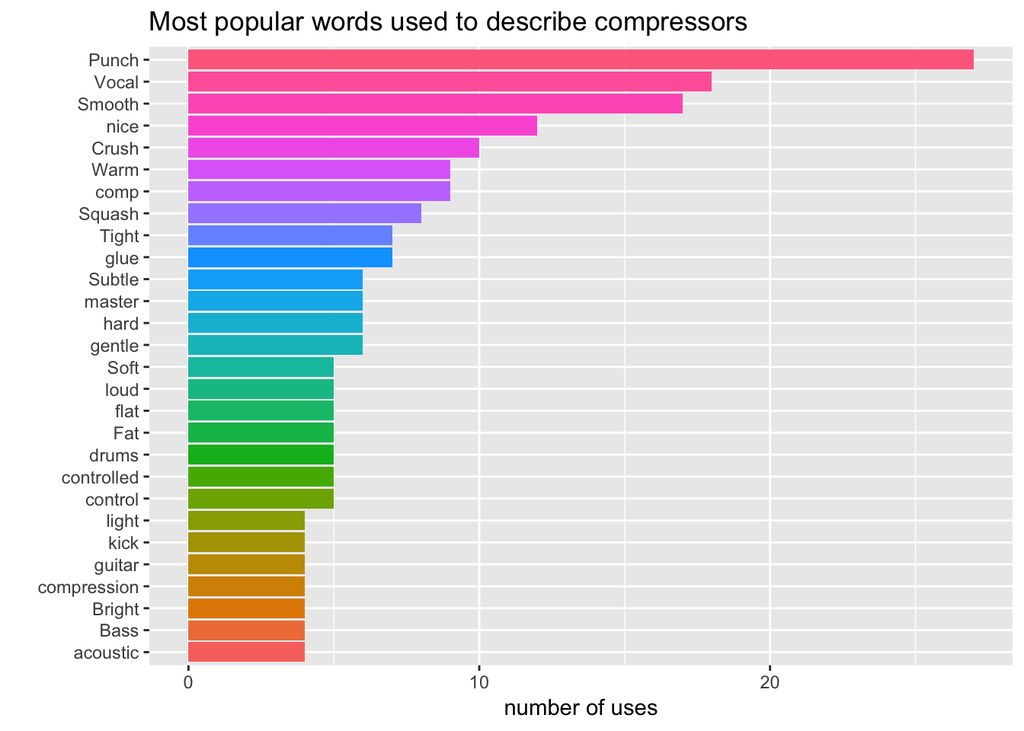

# Drum processing by effect type

Here, we can see the effects people choose to get a particular qualitative sound from their drum processing. E.g. if it’s *punch* you’re after (and by these data, chances are it is!), use a compressor and an EQ. If you want *crisp* or *bright*, turn to the EQ. And obviously, for *room* sound you’ll need a reverb.

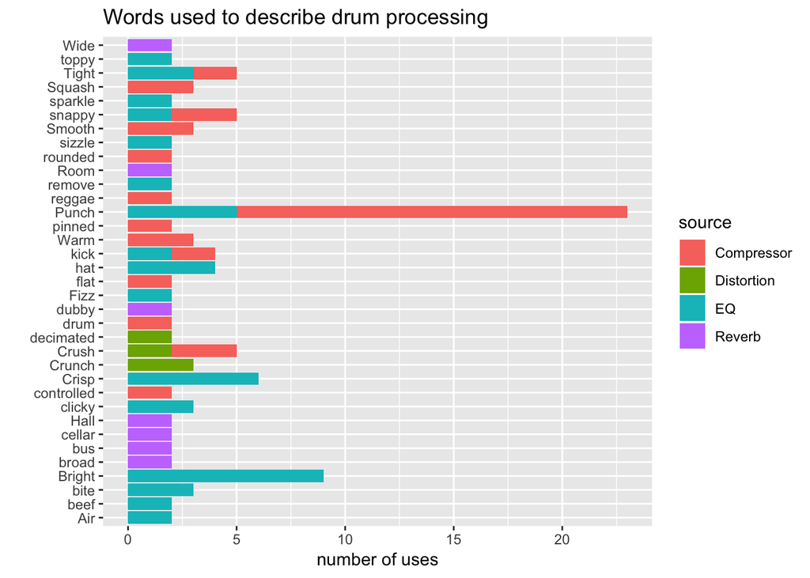

# The big ol’ chart of everything

I’ve tried to put it all together in one plot, grouping the most popular words for each of the most popular instruments, all coloured by the effect types used to achieve them. It’s not beautiful, but it’s kinda useful.

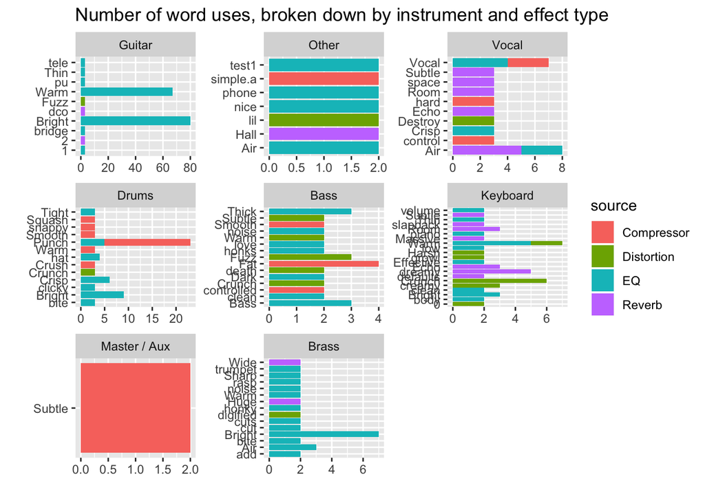

# Word clouds

Because you gotta have word clouds, here’s a cloud of the different terms people use for each type of effect. Note that I’ve dropped *warm* and *bright* so that the other words get a chance!

If you ask nicely, I’ll pour you a glass of my signature “Creamy Crunch Fuzz Punch” :)

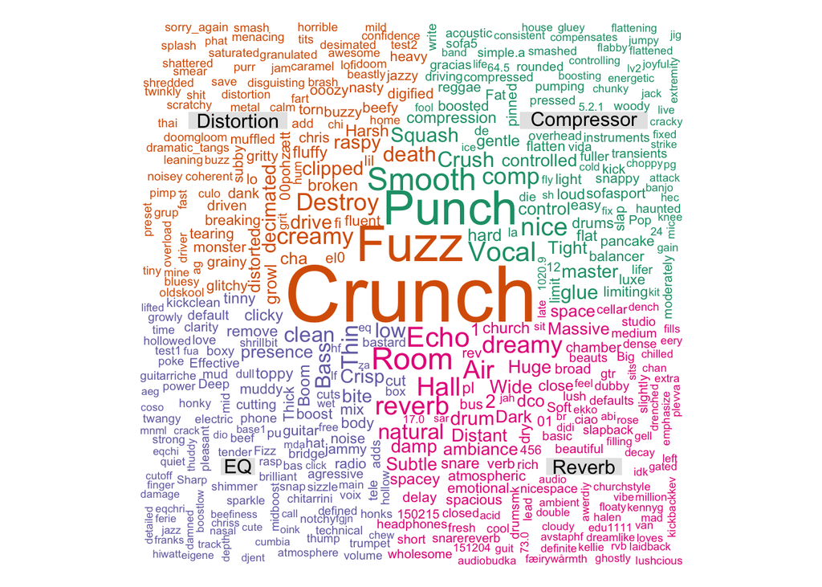

# Conclusions

So what can we conclude? We don’t really have enough data to say much more than:

1. Guitarists use EQ for *warmth* and *brightness*
2. Drummers want *punch*, and use a mixture of compression and EQ to achieve it
3. You’re gonna want some reverb and EQ to add *air* to your vocals
4. You might use a compressor for *fat* bass
5. Oh yeah, and *death to acoustic*! :D

I’d love to get about 10x more data and repeat this analysis. I’ve mailed this to the Semantic Audio folks, in the hope that the plugins are still gathering data!

# Footnotes

You may notice that sometimes the numbers don’t add up. This is because often the “instrument” field is left blank, so when aggregating by instrument, words don’t appear as often as they do in the absolute word breakdown. So be it.